# Ranked Sites for Intensive Sampling

NYS Department of Environmental Conservation

April 09, 2019

## Introduction

The purpose of this document is to rank the lakes screened in 2018 or sampled in the past 20 yrs by possible impacts for the purpose of selecting lakes that should be sampled intensively in 2019.

## Thresholds

The following are the thresholds used to identify possible impacts to drinking water, recreation, aquatic life, and trophic status. In addition to these, we also identified lakes that had any HAB detected since 2012.

|  | Designated_Use | classification | Characteristic.Name | Result.Sample.Fraction | direction | threshold | units | simpleWC | trout | Characteristic.Name2 | Result.Sample.Fraction2 | direction2 | threshold2 | X2 |
| --- | --- | --- | --- | --- | --- | --- | --- | --- | --- | --- | --- | --- | --- | --- |
| 1 | drinking_water | A | IRON |  | &gt; | 300 | ug/L |  |  |  |  |  |  |  |
| 2 | drinking_water | A | MANGANESE |  | &gt; | 300 | ug/L |  |  |  |  |  |  |  |
| 3 | drinking_water | A | ARSENIC |  | &gt; | 50 | ug/L |  |  |  |  |  |  |  |
| 4 | drinking_water | A | ARSENIC_MANGANESE |  | &gt; | 500 | ug/L |  |  |  |  |  |  |  |
| 5 | drinking_water | A | NITROGEN, NITRATE (AS N) |  | &gt; | 10 | mg/L |  |  |  |  |  |  |  |
| 6 | drinking_water | A | CHLORIDE |  | &gt; | 250 | mg/L |  |  |  |  |  |  |  |
| 7 | drinking_water | A | CHLOROPHYLL A |  | &gt; | 4 | ug/L | A |  |  |  |  |  |  |
| 8 | drinking_water | A | CHLOROPHYLL A |  | &gt; | 6 | ug/L | AA |  |  |  |  |  |  |
| 9 | drinking_water | A | UVDOC |  | &gt; | 4 |  |  |  |  |  |  |  |  |
| 10 | drinking_water | A | SULFATE (AS SO4) |  | &gt; | 250 | mg/L |  |  |  |  |  |  |  |

[output cut: 20 more lines]

## Ranked list of Lakes

The data used to produce this ranked list include screening 2018 data as well any data collected in the past 20 yrs from lakes listed in the waterbody inventory as needs verification, unassessed, or having minor impacts.

The lakes are ranked in the following order: PWS > Possible impacts to drinking water > Possible impacts to recreation > Possible impacts to aquatic life > Harmful algal bloom detected at least once since 2012 > Indicators of eutrophic conditions.

Historically, we’ve allocated $50,000 for LCI analytic costs, 2/3rds of which for Intensive sampling. The final column gives the analytic cost for intensively sampling each lake. If we stick with the 2/3rds of 50K budget, then that would allow us to sample all the sites through Silver Lake on this list. This is a satisfying cut off because that is the last lake that shows any impact to drinking water, recreation, aquatic life or HABs.

Total analytic costs for the lakes through Silver lake = $33,184.

|  | LAKE_ID | PWLID | basin | WATER | PWS | PIdrinking | PIrecreation | PIaquatic | bloom | eutrophic | mesotrophic | oligotrophic | year | hypo | Classification | Beaches | ACRES | WIPWL | cost |
| --- | --- | --- | --- | --- | --- | --- | --- | --- | --- | --- | --- | --- | --- | --- | --- | --- | --- | --- | --- |
| 36 | 1005BAR0338 | 1001-0027 | _10 | Bartlett Pond | Yes | 1 | 0 | 0 |  | 0 | 2 | 1 | 2018 |  | AAT | No | 96.2 |  | 936 |
| 27 | 1003ROL0168 | 1003-0100 | _10 | Rollins Pond |  | 13 | 1 | 0 |  | 3 | 17 | 2 | 2014 | yes | AAT | No | 446.8 | needs verification | 1496 |
| 35 | 1004UCA0271 | 1004-0075 | _10 | Upper Cascade Lake |  | 3 | 0 | 0 |  | 0 | 1 | 2 | 1999 | yes | AAT | No | 23.7 | needs verification | 1496 |
| 53 | 1701LAU0496 | 1701-0128 | _17 | Laurel Lake |  | 2 | 3 | 1 | yes | 6 | 0 | 0 | 2018 | yes | A(T) | No | 29.67 |  | 1496 |
| 56 | 1701MAR0495 | 1701-0129 | _17 | Maratooka Lake |  | 2 | 2 | 1 | yes | 6 | 0 | 0 | 2018 |  | A | No | 22.85 |  | 936 |
| 4 | 0601GIL0287 | 0601-0095 | _06 | Gilbert Lake |  | 2 | 0 | 0 | yes | 0 | 1 | 1 | 2018 | yes | AAT | Yes | 40.19 |  | 1496 |
| 42 | 1006CRA0380 |  | _10 | Cranberry Pond |  | 2 | 0 | 0 |  | 1 | 2 | 0 | 2018 |  | AA-S | No | 11.1 |  | 936 |
| 5 | 0601GOE0378 | 0601-0112 | _06 | Goey Pond |  | 2 | 0 | 0 |  | 0 | 0 | 2 | 2018 | yes | AA | No | 34.12 |  | 1496 |
| 70 | 1702SHE1087 | 1702-0067 | _17 | Sheldrake Lake |  | 1 | 2 | 1 | yes | 3 | 0 | 0 | 2018 |  | A | No | 24.8 |  | 936 |
| 28 | 1004LCA0270 | 1004-0075 | _10 | Lower Cascade Lake |  | 1 | 0 | 0 |  | 0 | 1 | 1 |  | yes | AAT | No | 25.7 | needs verification | 1496 |

[output cut: 34 more lines]

## Depth profiles

I’ve included the depth profiles for all the lakes for reference only.

### 0601ARN0362

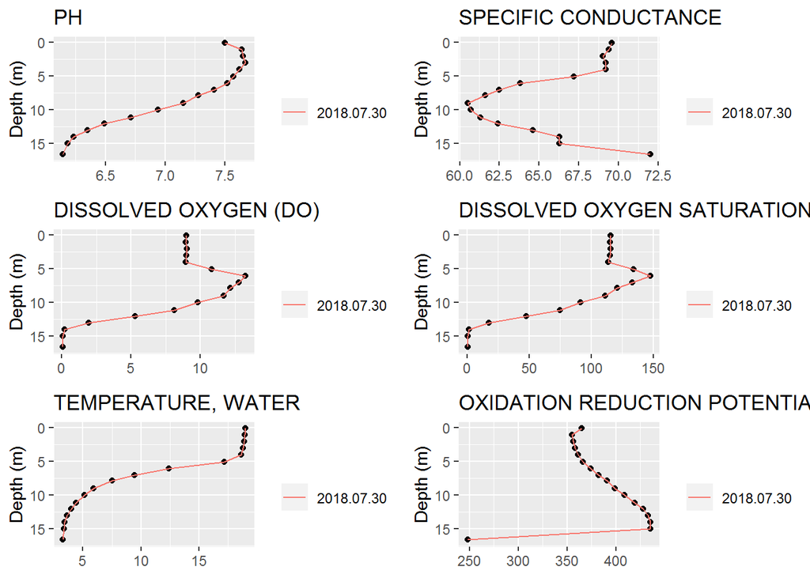

### 0601GIL0287

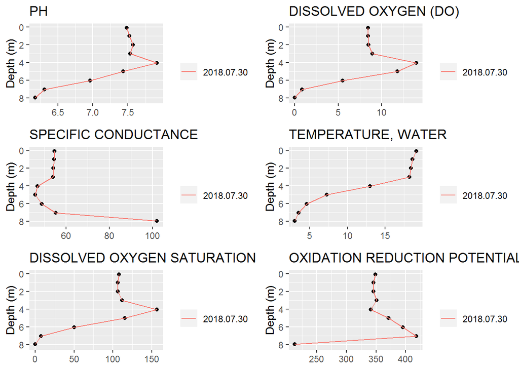

### 0601GOE0378

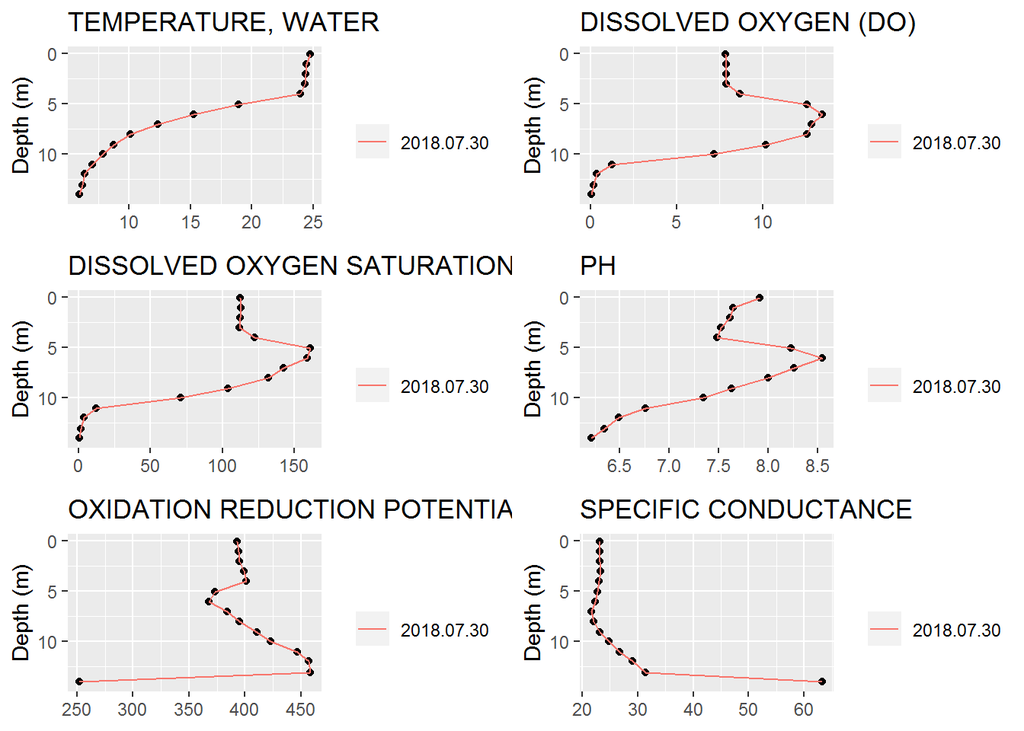

### 0602GLO0040

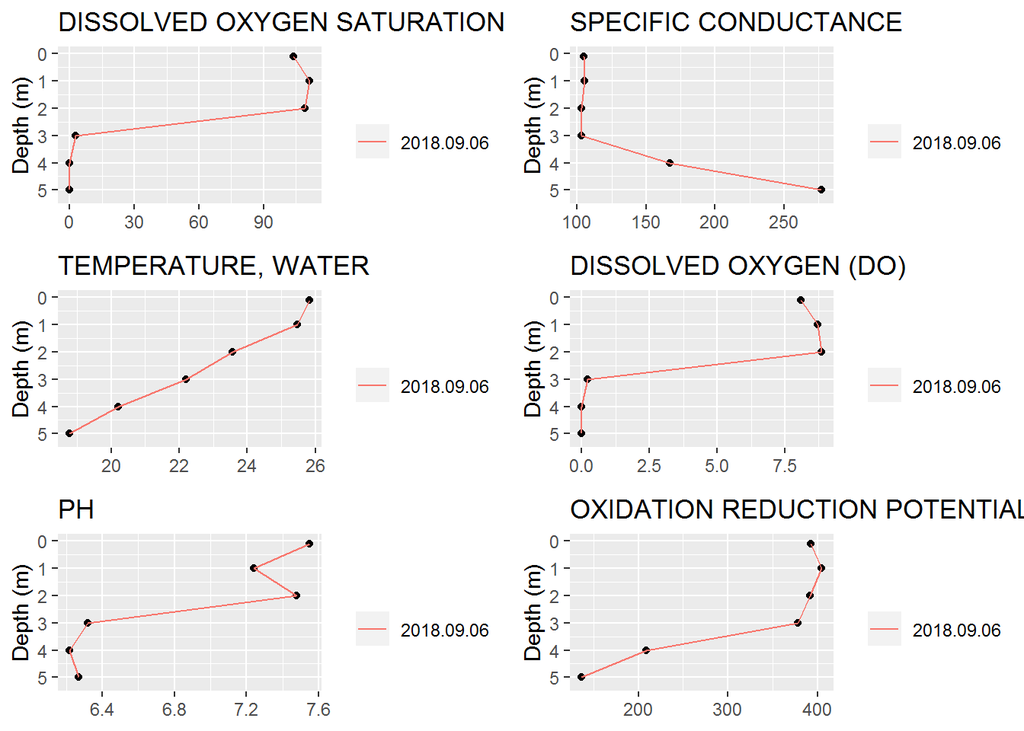

### 0602ROU0082

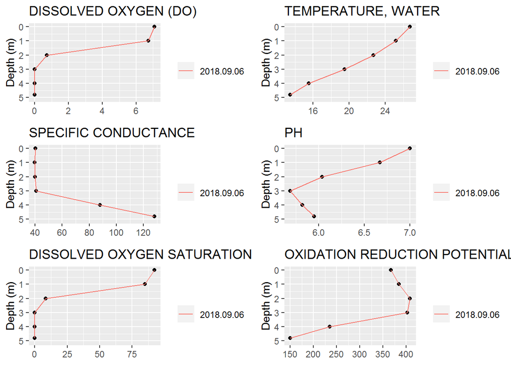

### 0602SHA5677

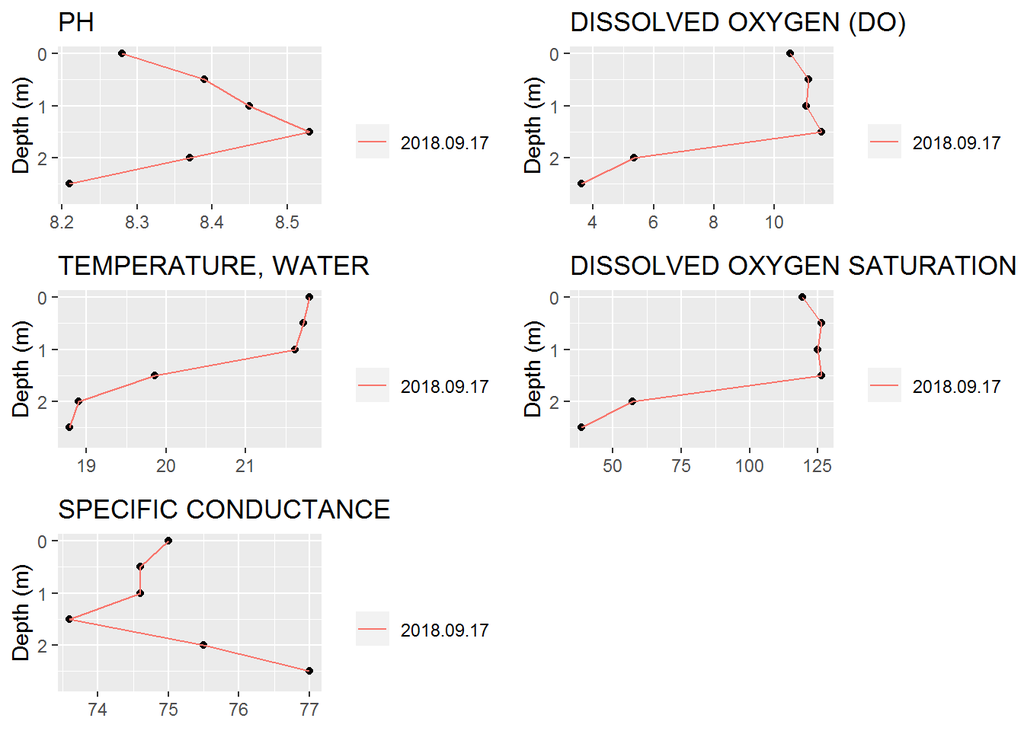

### 0602WHA5659

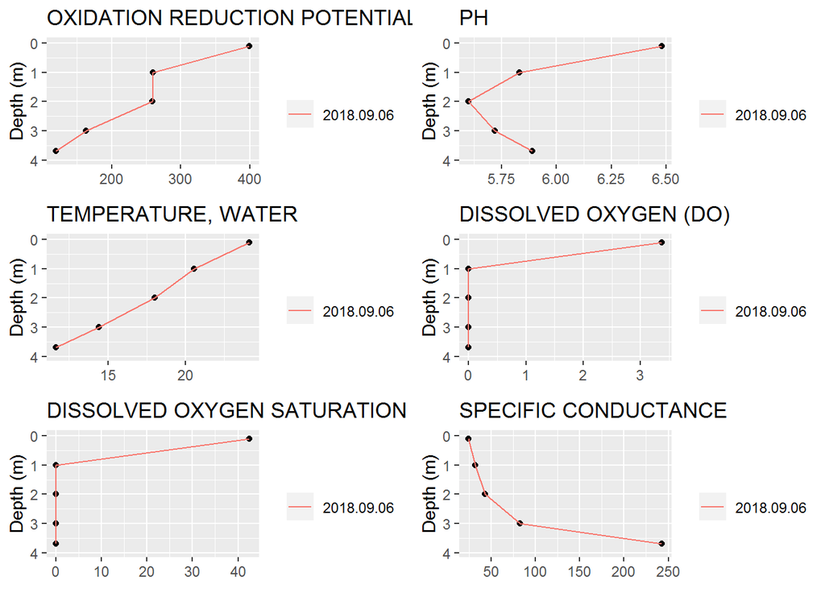

### 0902BAR0262

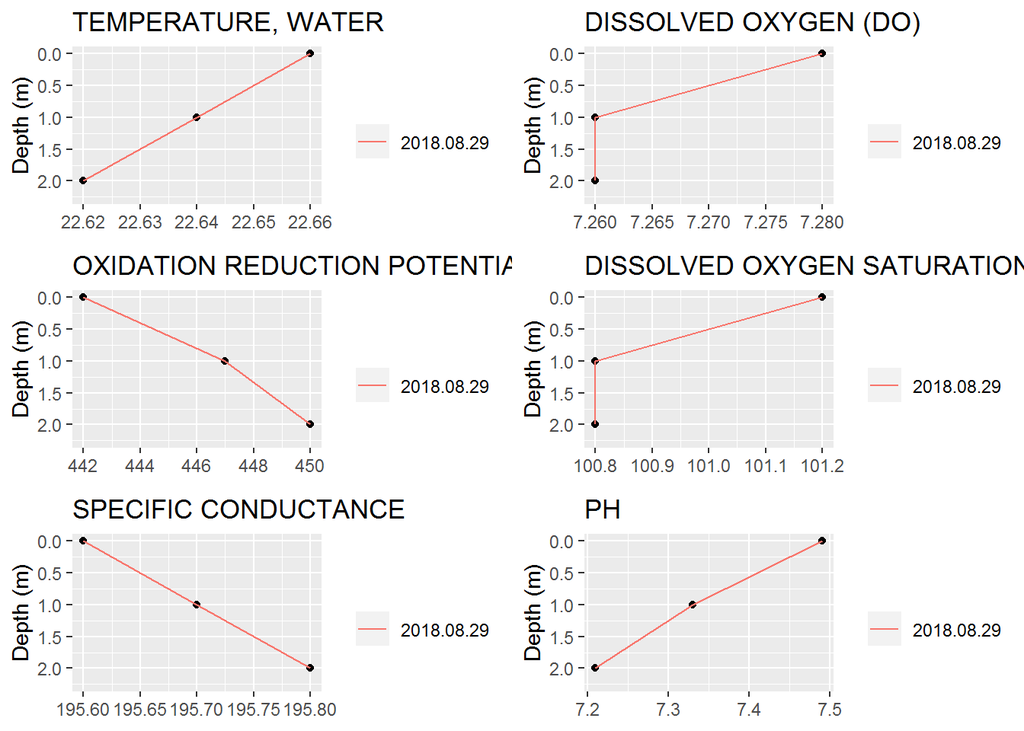

### 1003COL0106

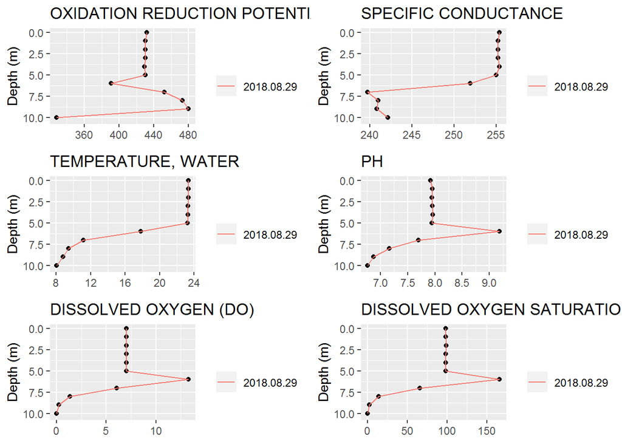

### 1003FRA5095

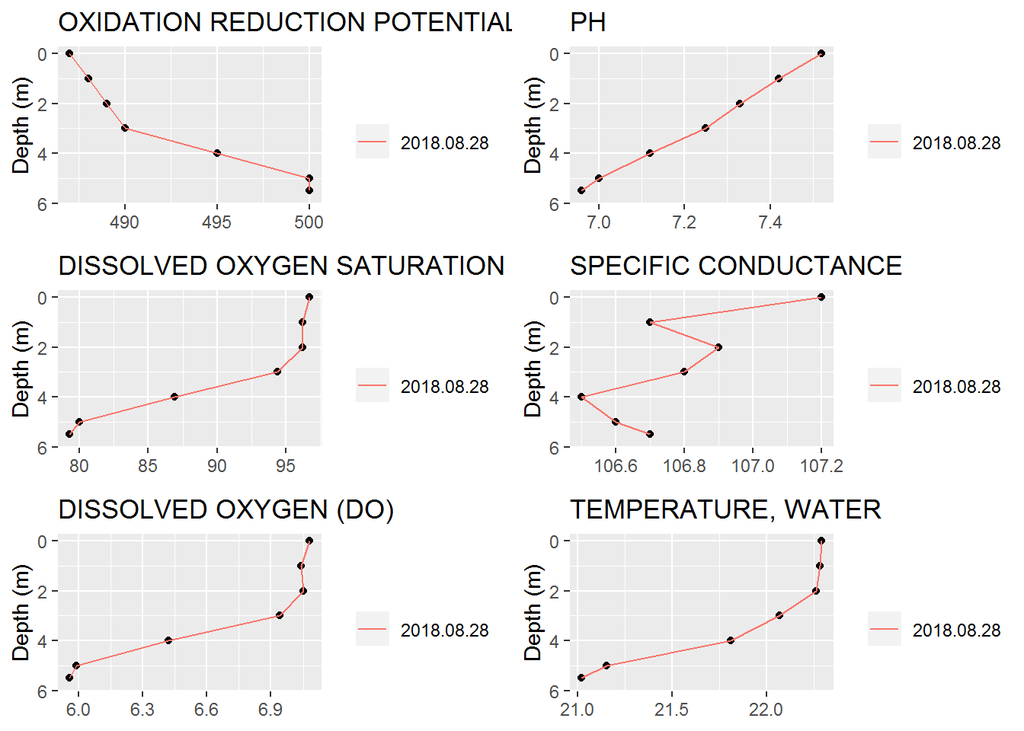

### 1003KUS0055

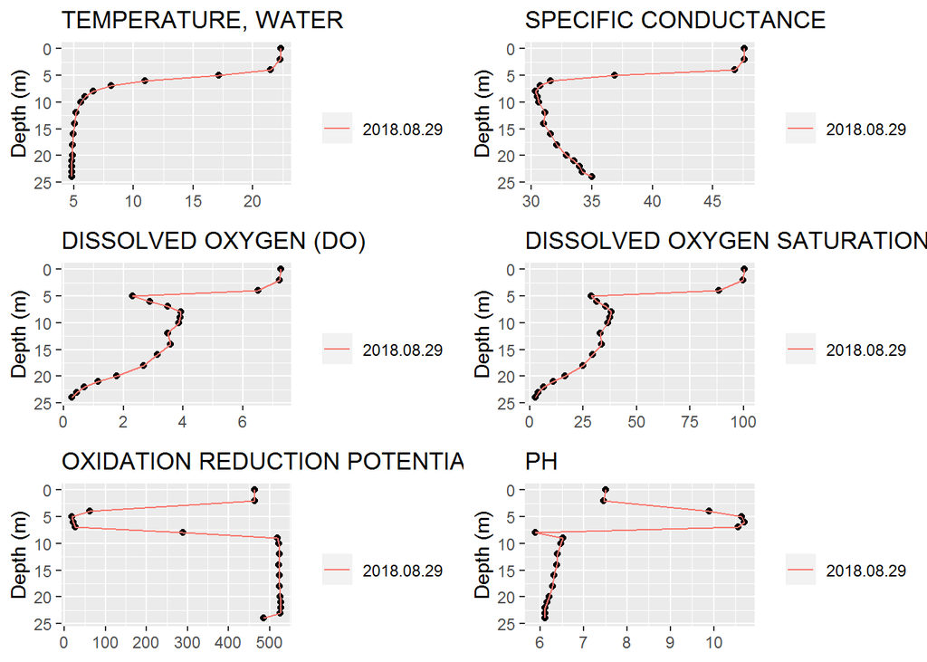

### 1003LSA0104

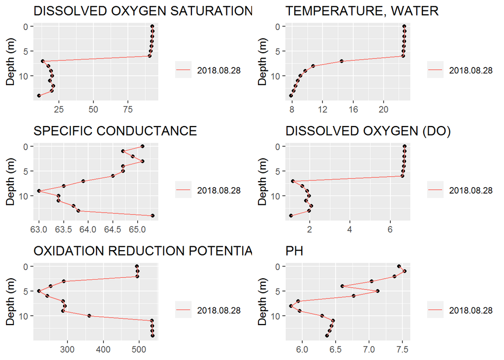

### 1003MOO0083

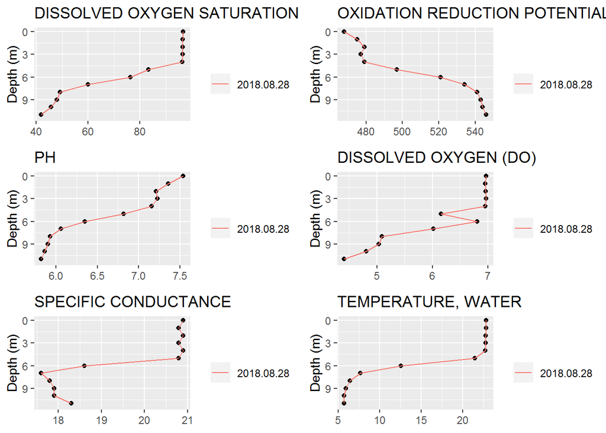

### 1004MIL0318

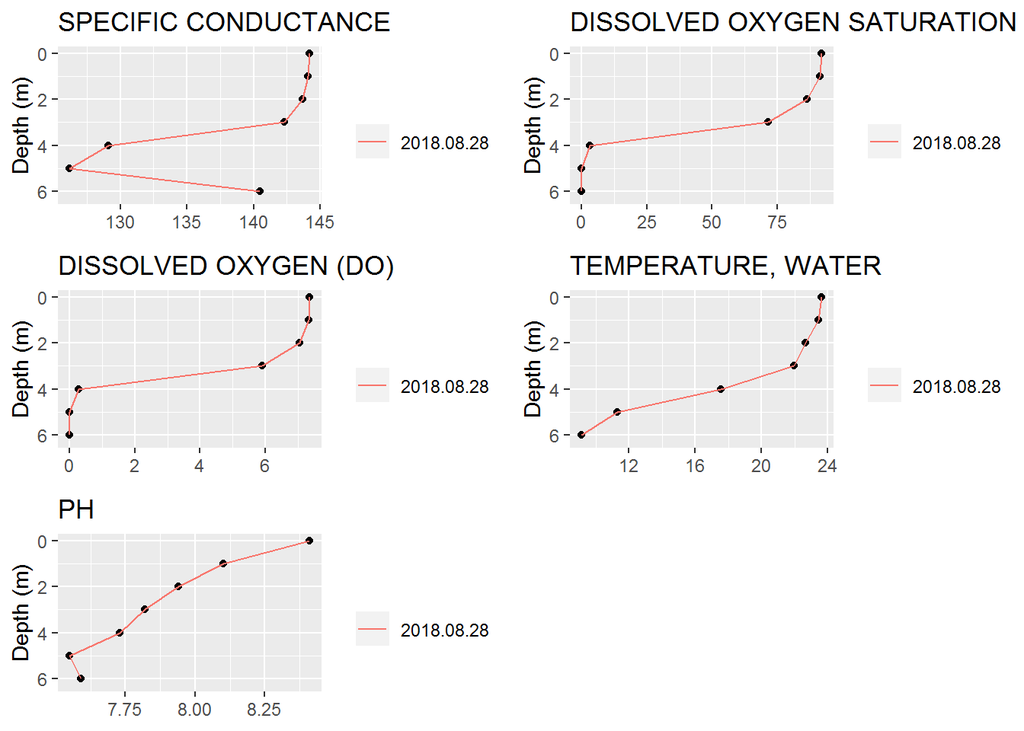

### 1004RUS0316

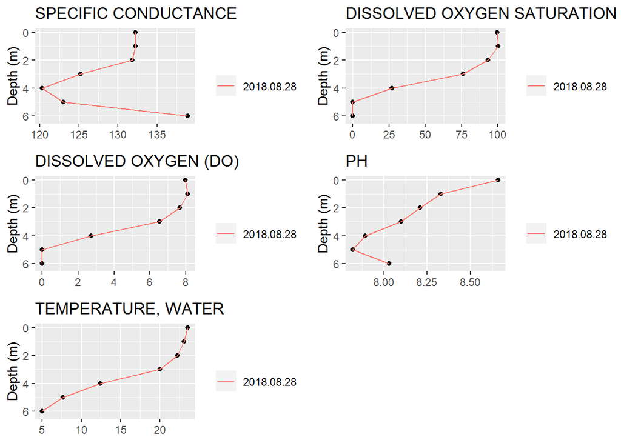

### 1005BAR0338

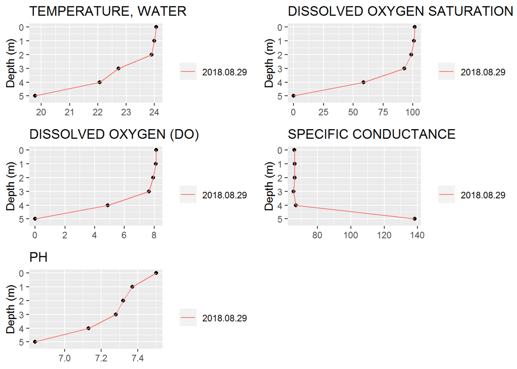

### 1005PEN0351A

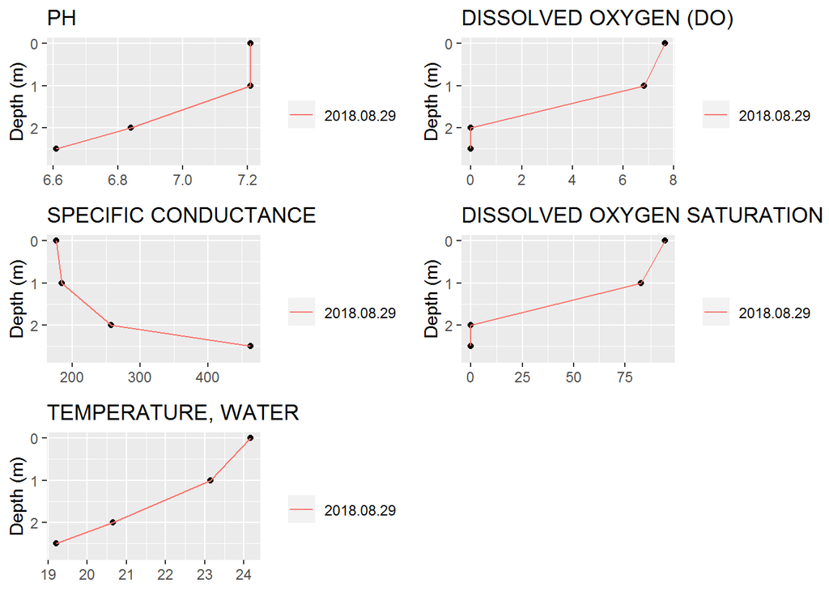

### 1006CRA0380

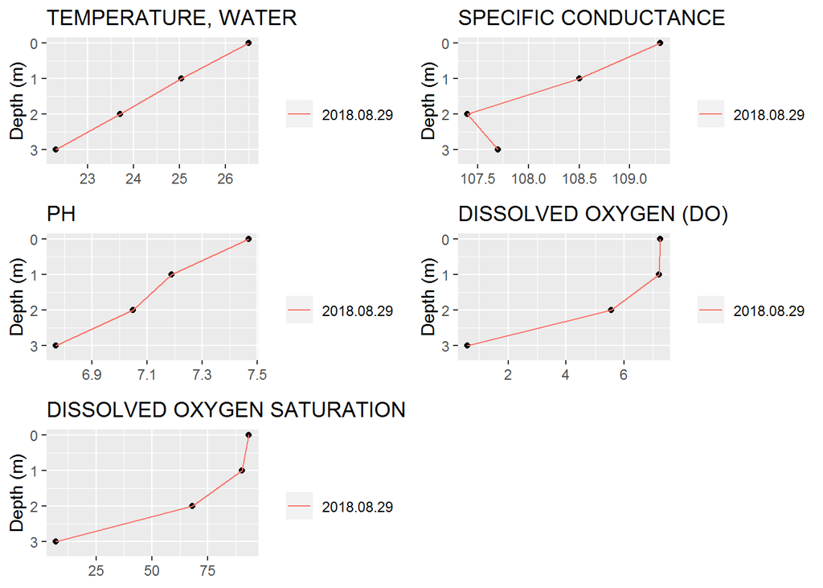

### 1006JAB0394

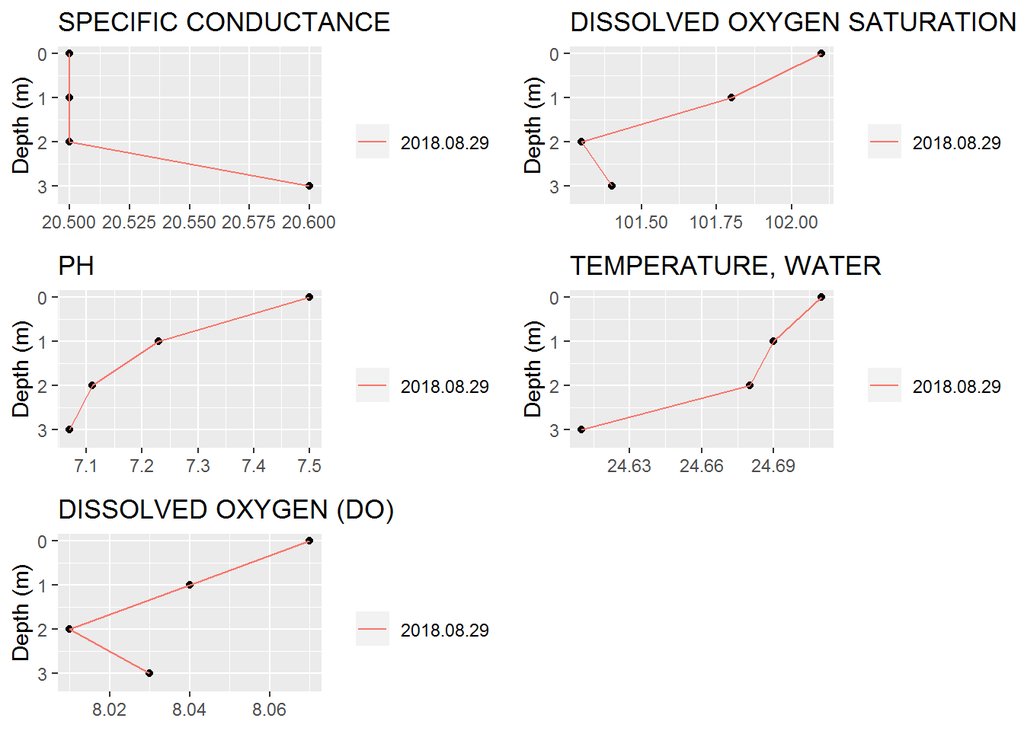

### 1701DON0565A

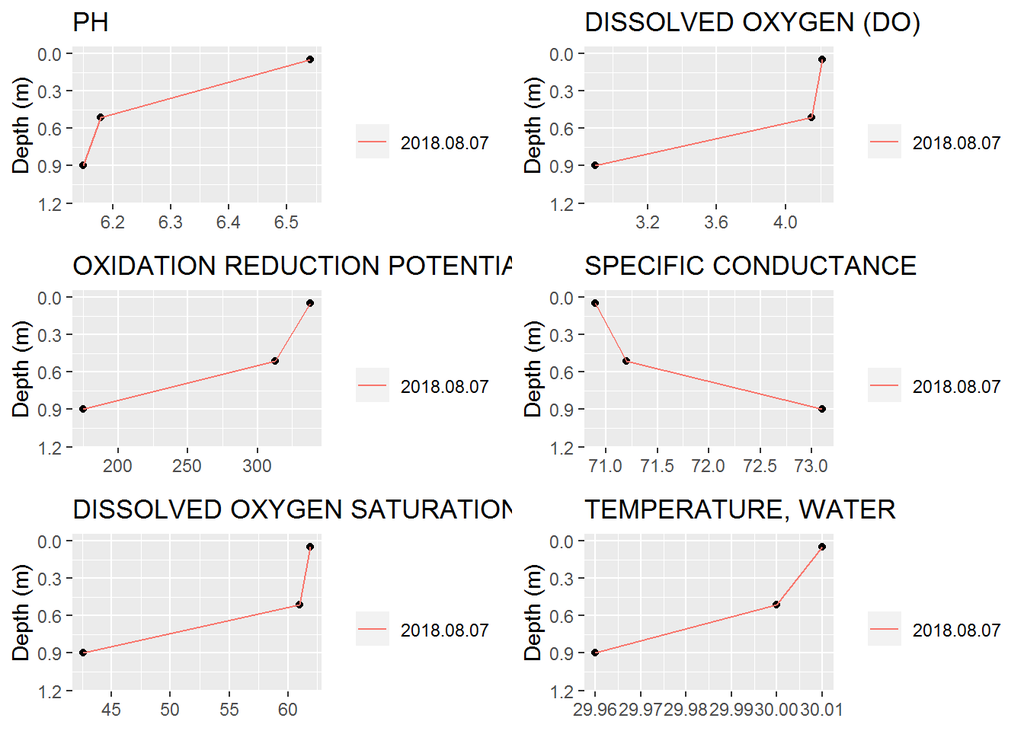

### 1701FRE0753

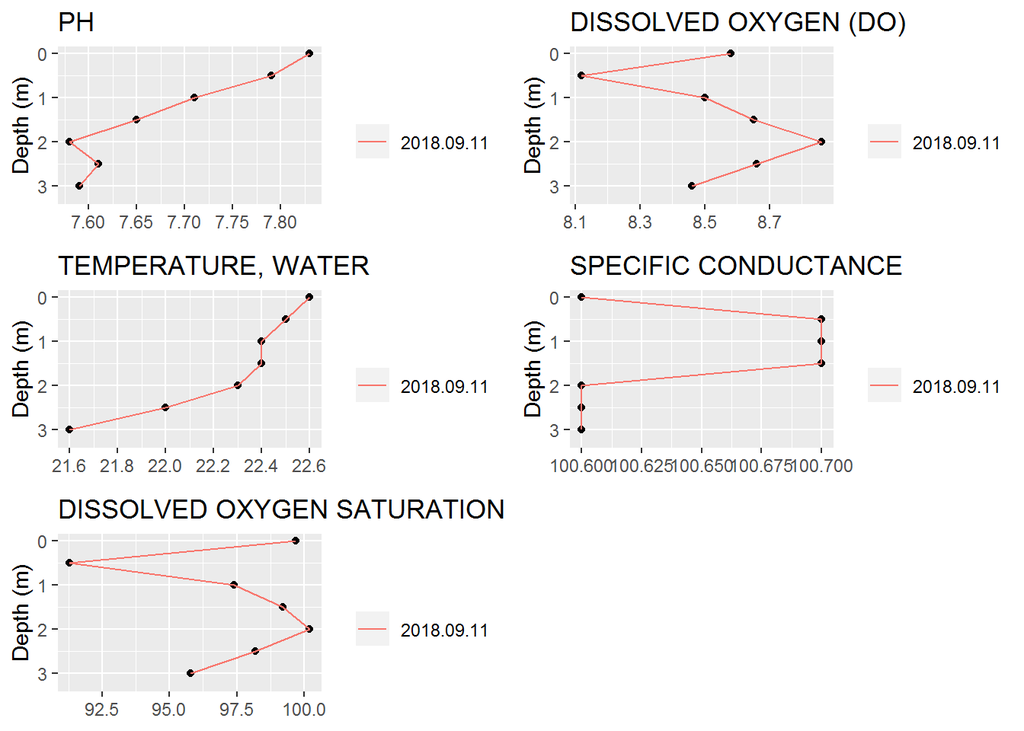

### 1701GRE0885

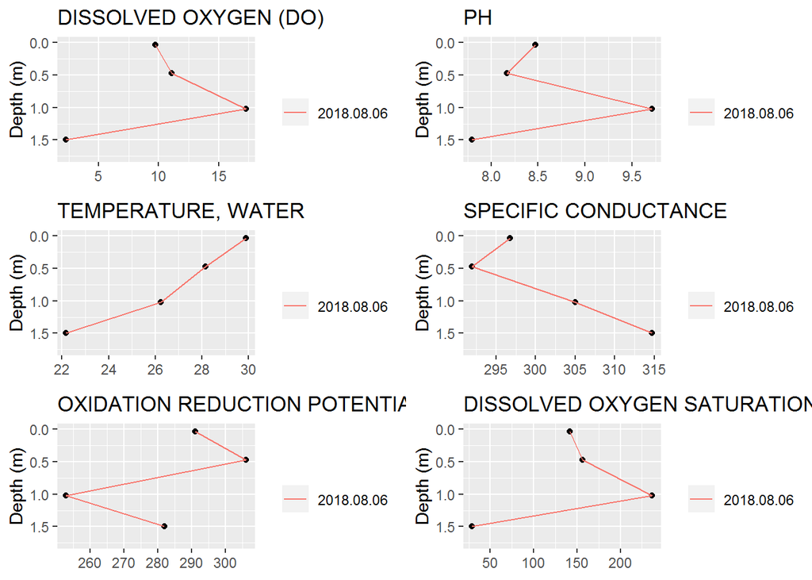

### 1701LAU0496

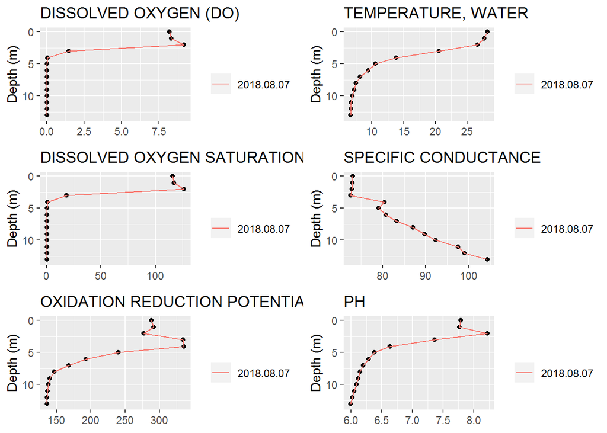

### 1701LOW0855

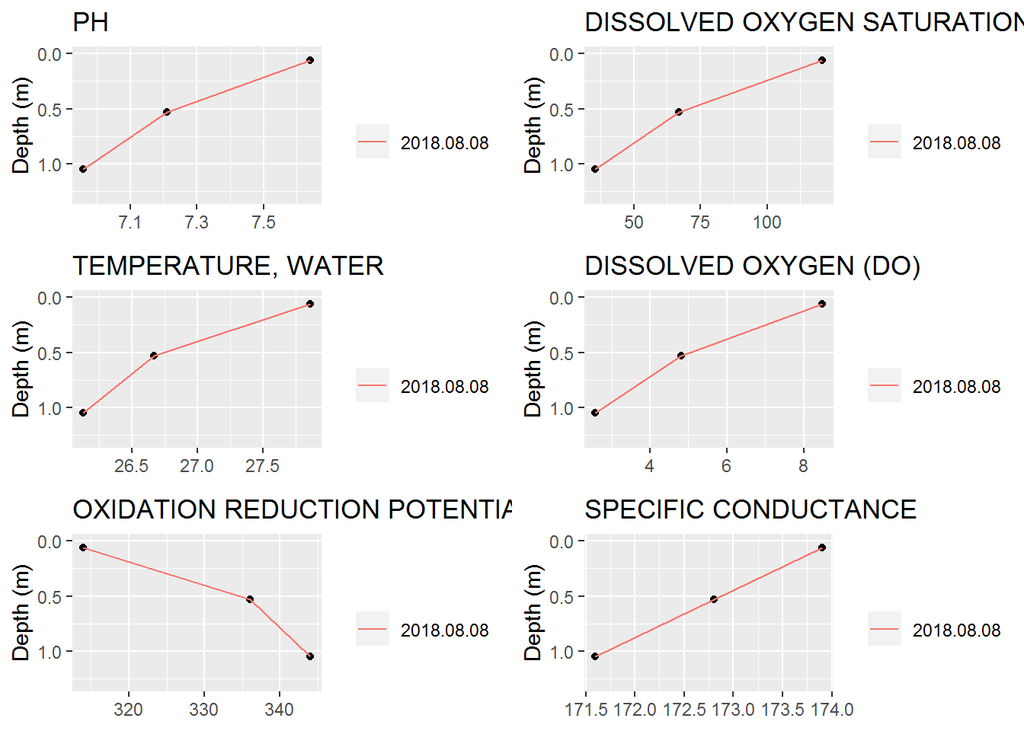

### 1701MAI0907

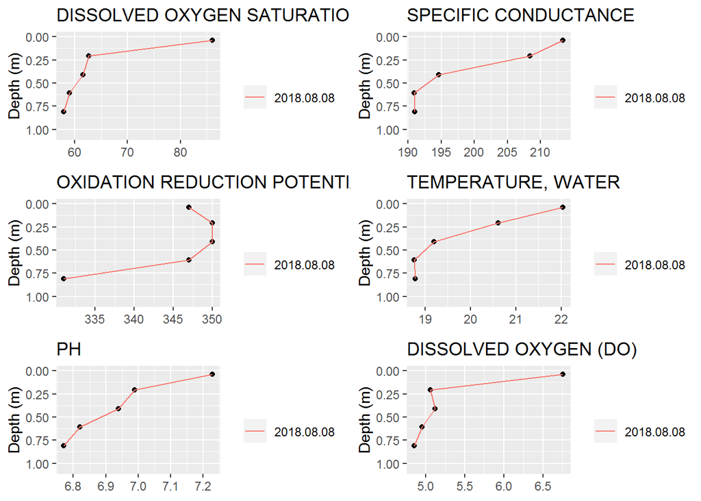

### 1701MAR0495

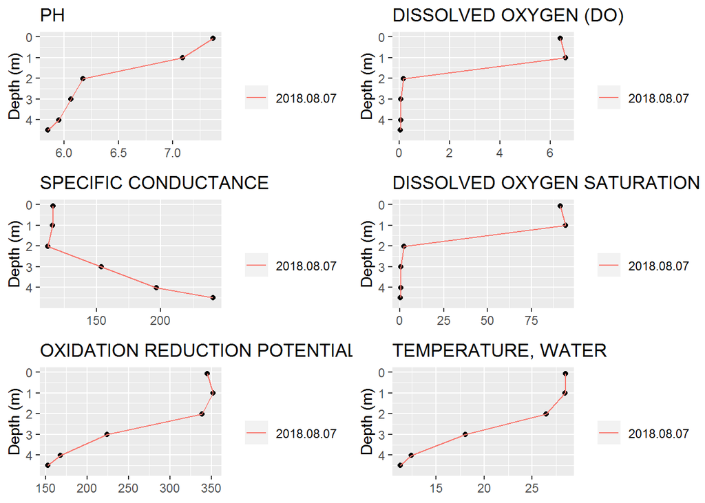

### 1701PEC0555

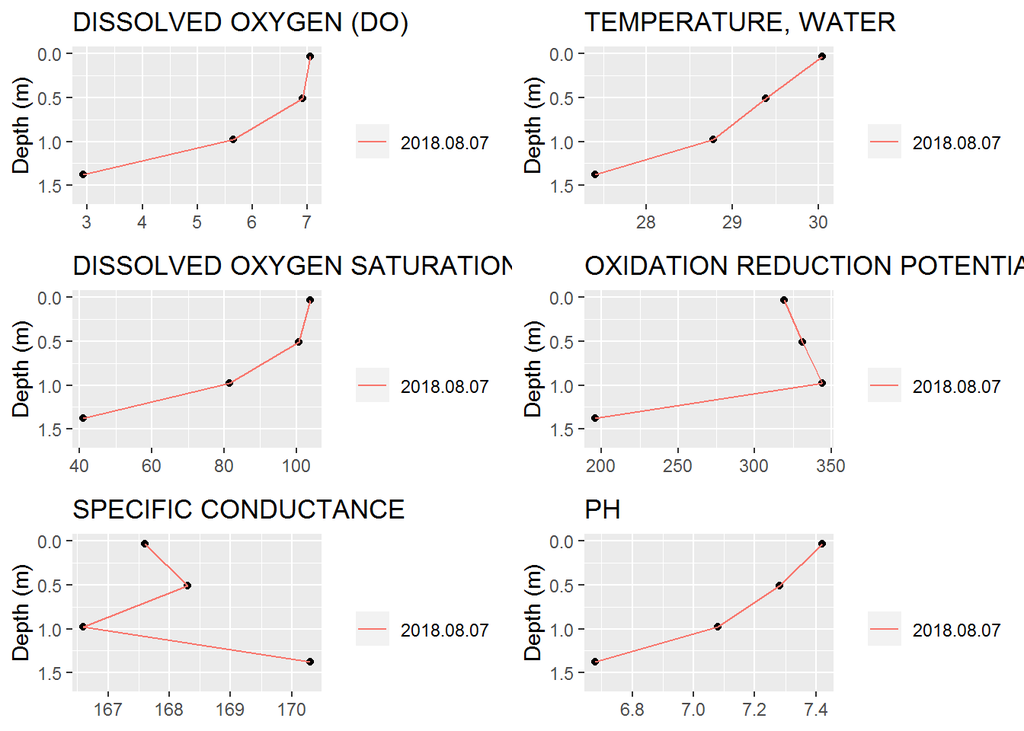

### 1701REE0763

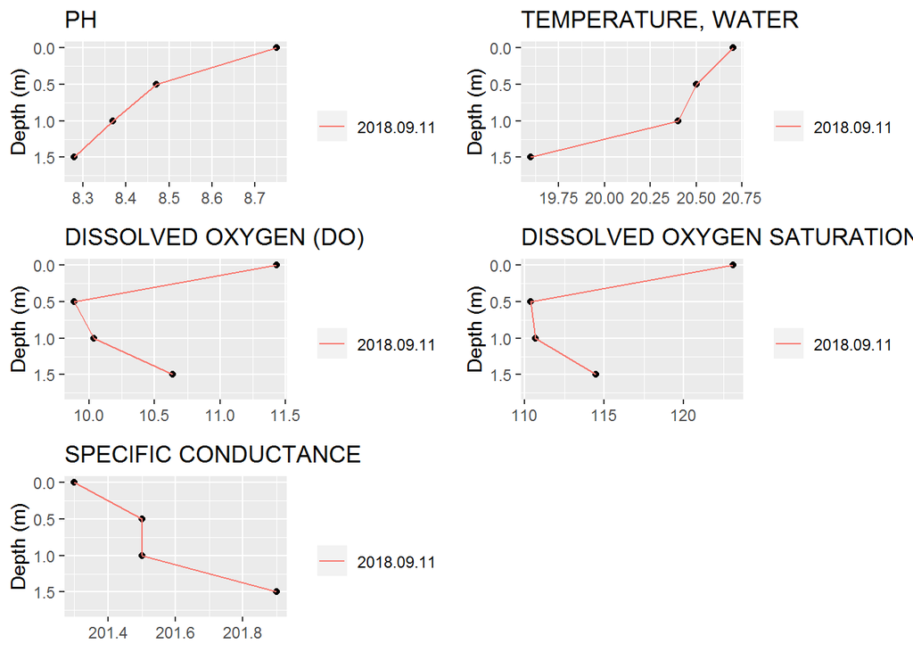

### 1702BRY1106

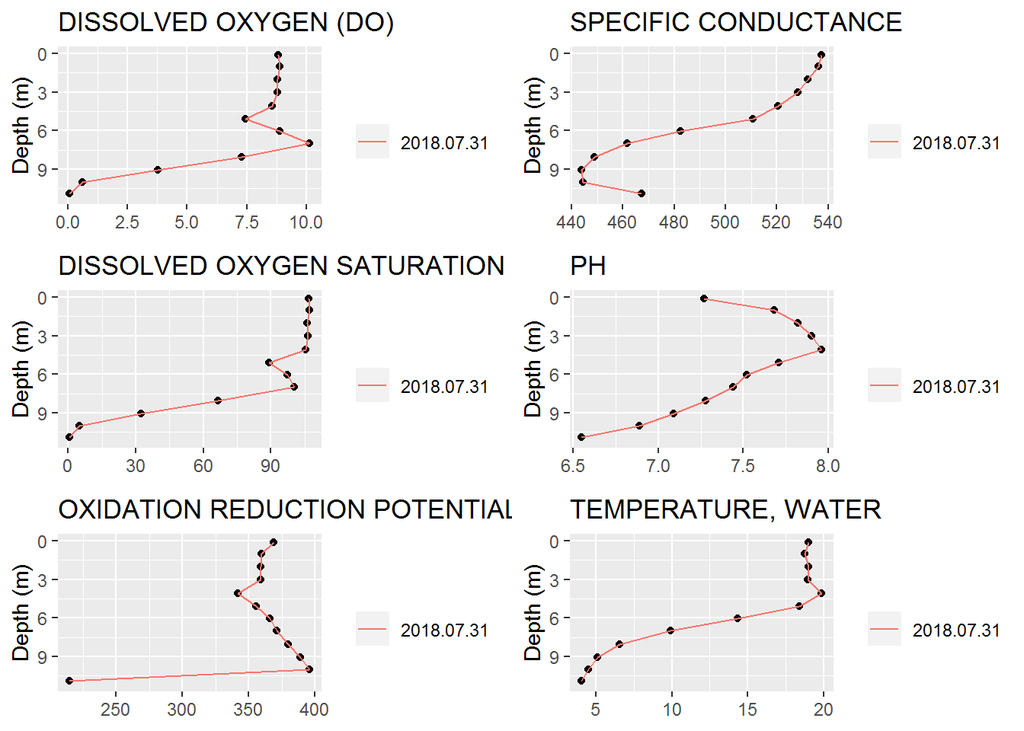

### 1702CLO1074

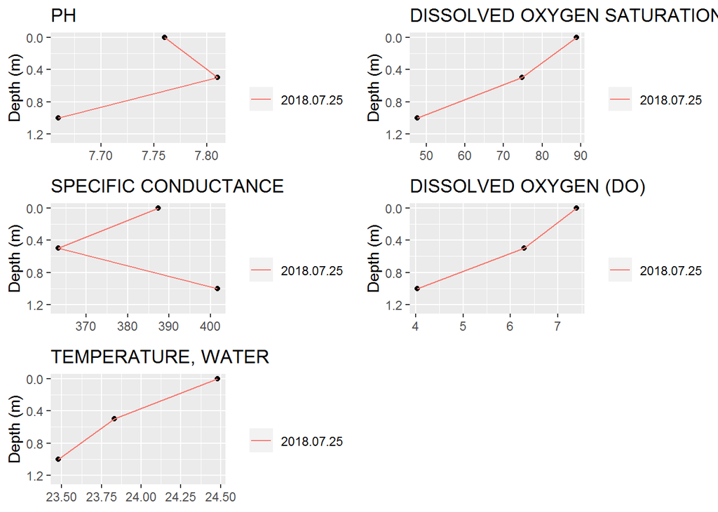

### 1702OAK0107

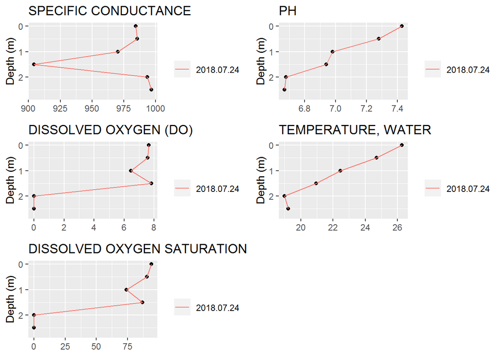